# SVM Lab II (L03)

Data Science III (STAT 301-3)

April 21rd, 2019

# Overview

The main goal of this lab is to continue practicing the application of support vector machines (SVMs).

# Datasets

We have split the `wildfires.csv` dataset into a training dataset (`wildfires_train.csv`) and test dataset (`wildfires_test.csv`). They are contained in the **data** subdirectory along with a codebook.

# Exercise

Please complete the following exercise. Be sure your solutions are clearly indicated and that the document is neatly formatted.

#### Load Packages

```r
# Loading package(s)
library(e1071)
library(tidyverse)
library(pROC)
library(randomForest)
library(xgboost)
```

#### Read in data

```r
# read in data
wildfires_train <- read_csv("data/wildfires_train.csv") %>%
  mutate(winddir = factor(winddir, levels = c("N", "NE", "E", "SE", "S", "SW", "W", "NW")),
         traffic = factor(traffic, levels = c("lo", "med", "hi")),
         wlf = factor(wlf, levels = c("0", "1")))
wildfires_test <- read_csv("data/wildfires_test.csv") %>%
  mutate(winddir = factor(winddir, levels = c("N", "NE", "E", "SE", "S", "SW", "W", "NW")),
         traffic = factor(traffic, levels = c("lo", "med", "hi")),
         wlf = factor(wlf, levels = c("0", "1")))
wildfires <- tibble(train = wildfires_train %>% list(),
                       test = wildfires_test %>% list())
```

## Exercise 1

Located in the northeast of the wilderness area is a wildlife protection zone. It is home to several rare and endangered species, and thus conservationists and park rangers are very interested in whether a given wildfire is likely to reach it.

```r
# cross validation to determine cost tuning parameter
set.seed(1)
linear_cv <- wildfires %>%
  mutate(train_cv = map(.x = train,
                               .f = function(x){
                                      return(tune(svm, wlf ~., data = x, kernel = "linear",
                                           ranges = list(cost = c(0.01, 0.1, 0.2, 0.3, 0.4, 0.5, 0.6, 0.7, 0.8, 0.9, 1, 5, 10)))
                                           )
                                 }))
# find the best cost
linear_cost <- linear_cv$train_cv[[1]]$best.parameters
linear_cost
```

```
##   cost
## 6  0.5
```

```r
# use best cost to build model
svm_linear_model <- wildfires %>%
  mutate(model_fit = map(.x = train, # fit the model
                         .f = function(x) svm(wlf ~ ., data = x,  kernel = "linear", cost = linear_cost,
                                        probability = TRUE)),
         train_pred = map2(model_fit, train,
                           ~ predict(.x, .y, probability = TRUE)), # get predictions on train set
         test_pred = map2(model_fit, test,
                          ~ predict(.x, .y, probability = TRUE)), # get predictions on test set
         confusion_matrix = map2(.x = test, .y = test_pred,  # get confusion matrix
                                 .f = function(x, y) caret::confusionMatrix(x$wlf, y)))

svm_linear_model$confusion_matrix[[1]]
```

```
## Confusion Matrix and Statistics
##
##           Reference
## Prediction  0  1
##          0 64 19
##          1 16 51
##
##                Accuracy : 0.7667
##                  95% CI : (0.6907, 0.8318)
##     No Information Rate : 0.5333
##     P-Value [Acc > NIR] : 2.993e-09
##
##                   Kappa : 0.53
##
##  Mcnemar's Test P-Value : 0.7353
##
##             Sensitivity : 0.8000
##             Specificity : 0.7286
##          Pos Pred Value : 0.7711
##          Neg Pred Value : 0.7612
##              Prevalence : 0.5333
##          Detection Rate : 0.4267
##    Detection Prevalence : 0.5533
##       Balanced Accuracy : 0.7643
##
##        'Positive' Class : 0
##
```

#### Radial kernel

2. Use the `tune()` function to select an optimal cost for a support vector machine (radial kernel). Use the default value for `gamma` and try to determine your own range of values for `cost` to explore. *Alternatively, you could use `tune()` to search for the optimal `cost` and `gamma`.*

```r
# cross validation to determine cost & gamma
set.seed(1)
radial_cv <- wildfires %>%
  mutate(train_cv = map(.x = train,
                        .f = function(x) tune(svm, wlf ~ ., data = x, kernel = "radial",
                                              ranges = list(cost = c(0.01, 0.1, 0.5, 1, 5, 8, 10),
                                                            gamma = c(0.001, 0.01, 0.05, 0.1, 0.5, 1)))))
# find the bset tuning parameters
radial_cost <- radial_cv$train_cv[[1]]$best.parameters[1]
radial_cost
```

```
##    cost
## 20    8
```

```r
radial_gamma <- radial_cv$train_cv[[1]]$best.parameters[2]
radial_gamma
```

```
##    gamma
## 20  0.05
```

```r
# use best parameters to build model
svm_radial_model <- wildfires %>%
  mutate(model_fit = map(.x = train,
                         .f = function(x) svm(wlf ~ ., data = x, kernel = "radial", cost = radial_cost,
                                              gamma = radial_gamma, probability = TRUE)),
         train_pred = map2(model_fit, train, ~ predict(.x, .y, probability = TRUE)), #train predictions
         test_pred = map2(model_fit, test, ~ predict(.x, .y, probability = TRUE)), # test predcitions
         confusion_matrix = map2(.x = test, .y = test_pred, # test confusion matrix
                               .f = function(x, y) caret::confusionMatrix(x$wlf, y)))

svm_radial_model$confusion_matrix[[1]]
```

```
## Confusion Matrix and Statistics
##
##           Reference
## Prediction  0  1
##          0 63 20
##          1 11 56
##
##                Accuracy : 0.7933
##                  95% CI : (0.7197, 0.8551)
##     No Information Rate : 0.5067
##     P-Value [Acc > NIR] : 3.773e-13
##
##                   Kappa : 0.5873
##
##  Mcnemar's Test P-Value : 0.1508
##
##             Sensitivity : 0.8514
##             Specificity : 0.7368
##          Pos Pred Value : 0.7590
##          Neg Pred Value : 0.8358
##              Prevalence : 0.4933
##          Detection Rate : 0.4200
##    Detection Prevalence : 0.5533
##       Balanced Accuracy : 0.7941
##
##        'Positive' Class : 0
##
```

#### Polynomial kernel

3. Use the `tune()` function to select an optimal cost for a support vector machine (polynomial kernel). Use the default value for `degree` and try to determine your own range of values for `cost` to explore. *Alternatively, you could use `tune()` to search for the optimal `cost` and `degree`.*

```r
# cross validation to determine cost & degree
set.seed(1)
polynomial_cv <- wildfires %>%
  mutate(train_cv = map(.x = train,
                        .f = function(x) tune(svm, wlf ~ ., data = x, kernel = "polynomial",
                                              ranges = list(cost = c(0.01, 0.1, 0.5, 1, 5, 8, 10),
                                                            gamma = c(0.001, 0.1 ,0.5, 1, 2, 3, 4),
                                                            degree = c(1 ,2, 3, 4)))))
# find the best tuning parameters
polynomial_cost <- polynomial_cv$train_cv[[1]]$best.parameters[1]
polynomial_cost
```

```
##    cost
## 92 0.01
```

```r
polynomial_gamma <- polynomial_cv$train_cv[[1]]$best.parameters[2]
polynomial_gamma
```

```
##    gamma
## 92     4
```

```r
polynomial_degree <- polynomial_cv$train_cv[[1]]$best.parameters[3]
polynomial_degree
```

```
##    degree
## 92      2
```

```r
# use best parameters to build model
svm_polynominal_model <- wildfires %>%
  mutate(model_fit = map(.x = train,
                         .f = function(x) svm(wlf ~ ., data = x, kernel = "polynomial",
                                              cost = polynomial_cost,
                                              gamma = polynomial_gamma, probability = TRUE)),
         train_pred = map2(model_fit, train, ~ predict(.x, .y, probability = TRUE)), # train predictions
         test_pred = map2(model_fit, test, ~ predict(.x, .y, probability = TRUE)), # test predcitions
         confusion_matrix = map2(.x = test, .y = test_pred, # test confusion matrix
                               .f = function(x, y) caret::confusionMatrix(x$wlf, y)))

svm_polynominal_model$confusion_matrix[[1]]
```

```
## Confusion Matrix and Statistics
##
##           Reference
## Prediction  0  1
##          0 58 25
##          1 17 50
##
##                Accuracy : 0.72
##                  95% CI : (0.6409, 0.7902)
##     No Information Rate : 0.5
##     P-Value [Acc > NIR] : 3.458e-08
##
##                   Kappa : 0.44
##
##  Mcnemar's Test P-Value : 0.2801
##
##             Sensitivity : 0.7733
##             Specificity : 0.6667
##          Pos Pred Value : 0.6988
##          Neg Pred Value : 0.7463
##              Prevalence : 0.5000
##          Detection Rate : 0.3867
##    Detection Prevalence : 0.5533
##       Balanced Accuracy : 0.7200
##
##        'Positive' Class : 0
##
```

#### Combine test error

Construct a table displaying the test error for these 3 candidate classifiers, the 3 candidate classifiers from the CART Lab II (L04), and the multiple logistic regression fit in CART Lab II (L04)

Calculate the test error for each of the 3 candidate classifiers selected in parts (1) - (3). Which classifier is the best?

```r
# classifier from the CART lab
set.seed(1)
wildfire_train <- read_csv("data/wildfires_train.csv") %>%
  mutate(winddir = factor(winddir, levels = c("N", "NE", "E", "SE", "S", "SW", "W", "NW")),
         traffic = factor(traffic, levels = c("lo", "med", "hi")))
wildfire_test <- read_csv("data/wildfires_test.csv") %>%
  mutate(winddir = factor(winddir, levels = c("N", "NE", "E", "SE", "S", "SW", "W", "NW")),
         traffic = factor(traffic, levels = c("lo", "med", "hi")))
wild <- wildfires_train %>%
  bind_rows(wildfires_test)
wildfire <- tibble(train = wildfire_train %>% list(),
                   test = wildfire_test %>% list())
```

```r
# mean test error for random forests, bagging and logistic regression
test_err <- function(mod_fit, df){
  df <- as_tibble(df)
  prob <- predict(mod_fit, newdata = df, type = "response")
  pred <- factor(if_else(prob > 0.5, 1, 0))
  return(mean(df$wlf != pred))
}
fitRF <- function(data, mtry){
  return(randomForest(wlf ~ ., data = data, mtry = mtry))
}
wlf_glm <- function(data){
    glm(wlf ~ ., data = data, family = binomial)
}

error_part1 <- wildfire %>%
  mutate(RandomForest = map2(train, 7, fitRF),
         Bagging = map2(train, 16, fitRF),
         Logistic = map(train, wlf_glm)) %>%
  gather(key = "model", value = "fit", RandomForest, Bagging, Logistic) %>%
  mutate(test_error = map2_dbl(fit, test, test_err))%>%
  select(model, test_error)

# mean test error for boosting
fitBoosting2 <- function(dat){
  dat = as_tibble(dat)
  mat = wild %>% dplyr::select(- wlf) %>% # encode on full boston df
    onehot::onehot() %>% # use onehot to encode variables
    predict(dat) # get OHE matrix
  return(xgb.DMatrix(data = mat, label = dat$wlf))
}
fit_wlf <- function(train_data, learning_rate, depth, nrounds, silent = 1){
  return(xgb.train(params = list(eta = learning_rate,
                          max_depth = depth,
                          silent = silent),
            train_data,
            nrounds = nrounds)
  )
}
xg_mse <- function(model, test){
  prob = predict(model, test, type = "response")
  vals = getinfo(test, "label")
  pred <- factor(if_else(prob > 0.5, 1, 0))
  mean(vals != pred)
}
error_part2 <- wildfire %>%
  mutate(train_dg = map(train, fitBoosting2),
         test_dg = map(test, fitBoosting2))%>%
  mutate(Boosting = map2(train_dg, 0.001, fit_wlf, depth = 10, nrounds = 5000)) %>%
  mutate(test_error = map2_dbl(Boosting, test_dg, xg_mse)) %>%
  gather(key = "model", value = "fit", Boosting) %>%
  select(model, test_error)

# test error for SVM
error_linear <- svm_linear_model %>%
  mutate(Linear_svm = model_fit,
         test_error = 1 - confusion_matrix[[1]]$overall[[1]]) %>%
  gather(key = "model", value = "fit", Linear_svm) %>%
  select(model, test_error)
error_radial <- svm_radial_model %>%
  mutate(Radial_svm = model_fit,
         test_error = 1 - confusion_matrix[[1]]$overall[[1]]) %>%
  gather(key = "model", value = "fit", Radial_svm) %>%
  select(model, test_error)
error_polynomial <- svm_radial_model %>%
  mutate(Polynomial_svm = model_fit,
         test_error = 1 - confusion_matrix[[1]]$overall[[1]]) %>%
  gather(key = "model", value = "fit", Polynomial_svm) %>%
  select(model, test_error)

# display all candidate classifier
error_part1 %>%
  bind_rows(error_part2,
           error_linear,
           error_radial,
           error_polynomial)
```

[output not shown]

## Challenge (Not Mandatory)

Use the `ggroc()` function from the `pROC` package to construct ROC curves for the 3 SVM candidate classifiers from above. Do this for each classifier on both the training and testing sets.

```r
# helper functions
get_probs <- function(pred){
  attributes(pred)$probabilities %>%
    data.frame() %>%
    select(X1) %>%
    as_vector() %>%
    return()
}

roc_svm <- function(data, pred){
  pROC::roc(data$wlf, pred)
}

Linear_roc <- svm_linear_model %>%
  mutate(train_pred_prob = map(train_pred, get_probs),
         train_roc = map2(train, train_pred_prob, roc_svm),
         train_roc_plot = map(train_roc, ggroc),
         test_pred_prob = map(test_pred, get_probs),
         test_roc = map2(test, test_pred_prob, roc_svm),
         test_roc_plot = map(test_roc, ggroc))
Radial_roc <- svm_radial_model %>%
  mutate(train_pred_prob = map(train_pred, get_probs),
         train_roc = map2(train, train_pred_prob, roc_svm),
         train_roc_plot = map(train_roc, ggroc),
         test_pred_prob = map(test_pred, get_probs),
         test_roc = map2(test, test_pred_prob, roc_svm),
         test_roc_plot = map(test_roc, ggroc))
Polynomial_roc <- svm_polynominal_model %>%
  mutate(train_pred_prob = map(train_pred, get_probs),
         train_roc = map2(train, train_pred_prob, roc_svm),
         train_roc_plot = map(train_roc, ggroc),
         test_pred_prob = map(test_pred, get_probs),
         test_roc = map2(test, test_pred_prob, roc_svm),
         test_roc_plot = map(test_roc, ggroc))
```

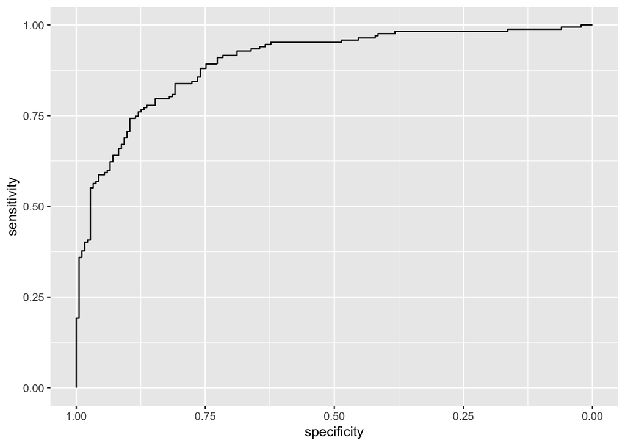

```r
Linear_roc %>%
  pluck("train_roc_plot", 1)
```

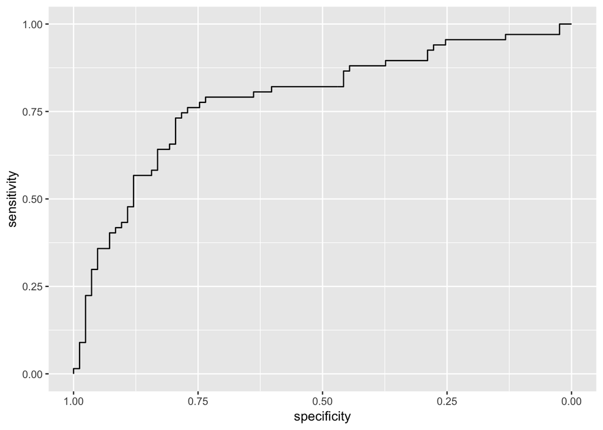

```r
Linear_roc %>%
  pluck("test_roc_plot", 1)
```

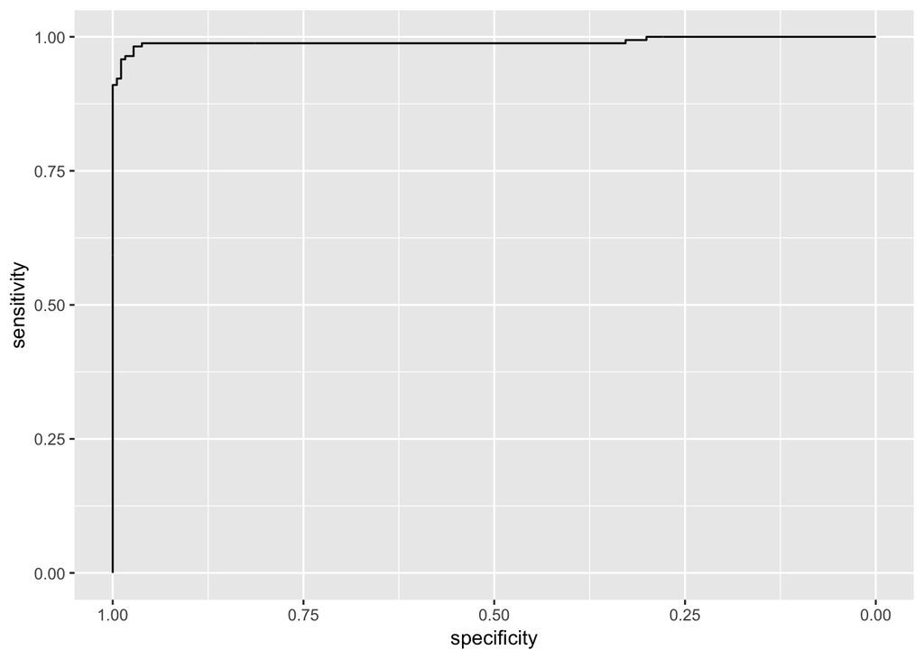

```r
Radial_roc %>%
  pluck("train_roc_plot", 1)
```

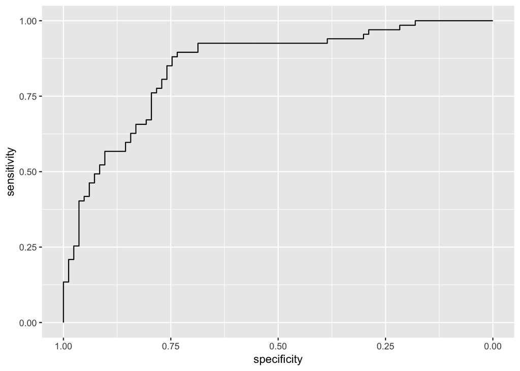

```r
Radial_roc %>%
  pluck("test_roc_plot", 1)
```

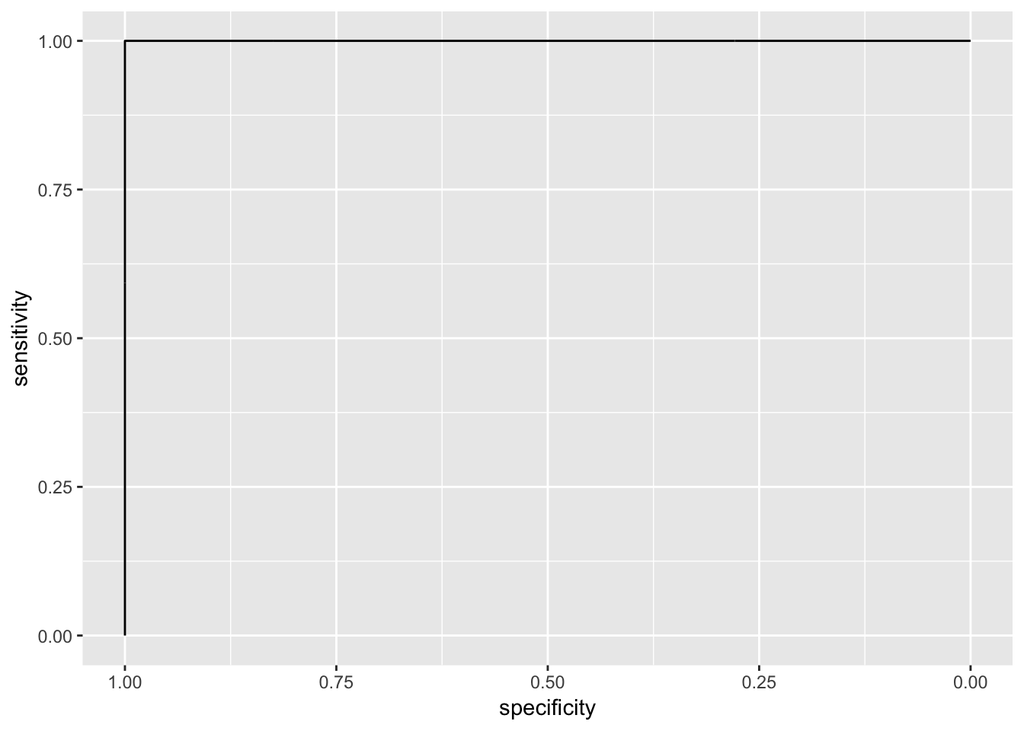

```r
Polynomial_roc %>%
  pluck("train_roc_plot", 1)
```

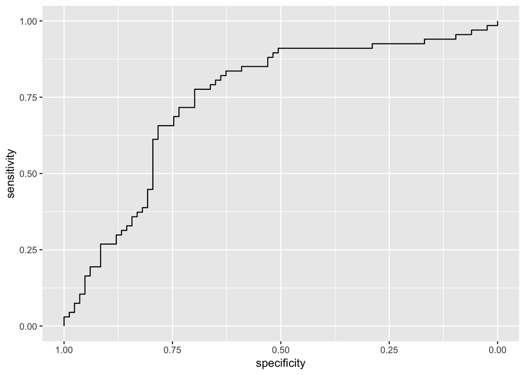

```r
Polynomial_roc %>%
  pluck("test_roc_plot", 1)
```